# Reproducible Research Course Project 1

Luke Soltis

July 18, 2016

Introduction

“It is now possible to collect a large amount of data about personal movement using activity monitoring devices such as a Fitbit, Nike Fuelband, or Jawbone Up. These type of devices are part of the”quantified self" movement - a group of enthusiasts who take measurements about themselves regularly to improve their health, to find patterns in their behavior, or because they are tech geeks. But these data remain under-utilized both because the raw data are hard to obtain and there is a lack of statistical methods and software for processing and interpreting the data.

This assignment makes use of data from a personal activity monitoring device. This device collects data at 5 minute intervals through out the day. The data consists of two months of data from an anonymous individual collected during the months of October and November, 2012 and include the number of steps taken in 5 minute intervals each day.

The data for this assignment can be downloaded from the course web site:

Dataset: Activity monitoring data [52K] The variables included in this dataset are:

steps: Number of steps taking in a 5-minute interval (missing values are coded as NA) date: The date on which the measurement was taken in YYYY-MM-DD format interval: Identifier for the 5-minute interval in which measurement was taken The dataset is stored in a comma-separated-value (CSV) file and there are a total of 17,568 observations in this dataset."

Code for reading in the dataset and/or processing the data

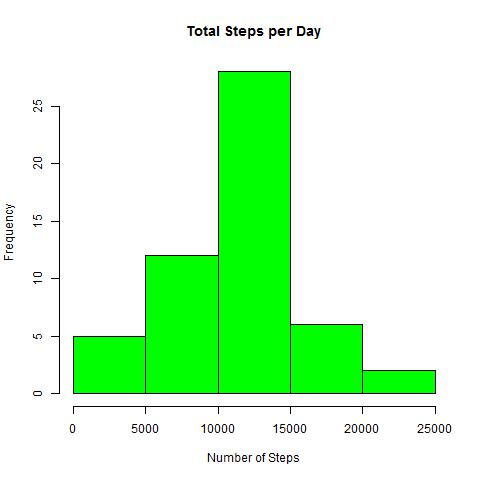

```r
library(ggplot2)
library(lubridate)
library(dplyr)
library(lattice)
library(raster)
setwd("C:/Users/Luke/Documents/Coursera")
data <- read.csv("activity.csv")

stepsbyday <- aggregate(steps ~ date, data, sum)
jpeg('plot1.jpg')
hist(stepsbyday$steps, main = paste("Total Steps per Day"), col = "green", xlab = "Number of Steps")
dev.off()
```

```r
stepmean <- mean(stepsbyday$steps)
stepmedian <- median(stepsbyday$steps)
```

Time series plot of the average number of steps taken

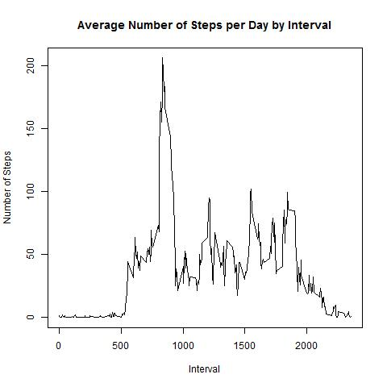

```r
stepsinterval <- aggregate(steps ~ interval, data, mean)

jpeg('plot2.jpg')
plot(stepsinterval$interval, stepsinterval$steps, type = "l", xlab = "Interval", ylab = "Number of Steps", main = "Average Number of Steps per Day by Interval")
dev.off()
```

```r
maxinterval <- stepsinterval[which.max(stepsinterval$steps), 1]
```

Code to describe and show a strategy for imputing missing data

```r
missing <- sum(!complete.cases(data))
imputeddata <- transform(data, steps = ifelse(is.na(data$steps), stepsinterval$steps[match(data$interval, stepsinterval$interval)], data$steps))

imputeddata[as.character(imputeddata$date) == "2012-10-01", 1] <- 0
```

Histogram of the total number of steps taken each day after missing values are imputed

```r
jpeg('plot3.jpg')
stepsbydayi <- aggregate(steps ~ date, imputeddata, sum)
hist(stepsbydayi$steps, main = paste("Total Steps Each Day"), col = "blue", xlab = "Number of Steps")

hist(stepsbyday$steps, main = paste("Total Steps Each Day"), col="green", xlab="Number of Steps", add=T)
legend("topright", c("Imputed", "Non-imputed"), col=c("blue", "green"), lwd=10)
dev.off()
```

```r
stepmean.i <- mean(stepsbydayi$steps)
stepmedian.i <- median(stepsbydayi$steps)

mean_diff <- stepmean.i-stepmean
med_diff <- stepmedian.i-stepmedian


total_diff <- sum(stepsbydayi$steps) - sum(stepsbyday$steps)
```

[figure not shown]

Panel plot comparing the average number of steps taken per 5-minute interval across weekdays and weekends

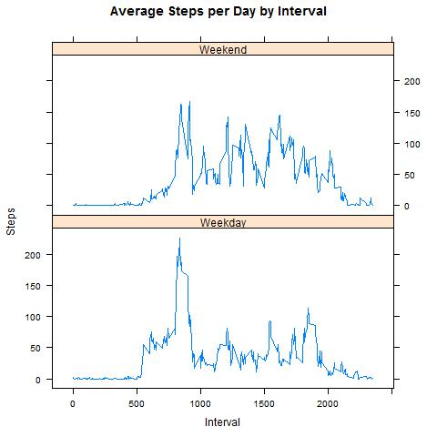

```r
  weekdays <- c("Monday", "Tuesday", "Wednesday", "Thursday",
              "Friday")
imputeddata$dow = as.factor(ifelse(is.element(weekdays(as.Date(imputeddata$date)),weekdays), "Weekday", "Weekend"))

stepsbyintervali <- aggregate(steps ~ interval + dow, imputeddata, mean)

jpeg('plot4.jpg')
xyplot(stepsbyintervali$steps ~ stepsbyintervali$interval|stepsbyintervali$dow, main = "Average Steps per Day by Interval", xlab = "Interval", ylab = "Steps", layout = c(1,2), type = "l")
  dev.off()
```